# Job Openings and Labor Turnover Survey (JOLTS) February 2024 update

Ted Schurter

February 01, 2024

##### The Job Openings and Labor Turnover Survey (JOLTS) uses data from a sample of approximately 21,000 businesses that cover nonagricultural industries in the public and private sectors of all 50 states and the District of Columbia to provide an indicator of labor demand and shortages at the national level. More information about the survey can be found at the Bureau of Labor Statistics [website.](https://www.bls.gov/jlt/)

##### This brief report details the levels and rates of job openings and total separations, as well as hires, quits, layoffs and discharges for 10-year and 12-month periods. Data can be downloaded as csv or Excel files using the Data tabs. The most recent month’s data is preliminary.

### **Job openings and Total separations**

##### The seasonally adjusted job openings rate remained at 5.4% in December, below the 5.7% 12-month average, 0.7% above the ten-year average rate for the month; there were 9.0 million job openings. The total separations rate remained at 3.4% in December, below the 3.6% 12-month average, and 0.25% below the ten-year average rate for the month; there were 5.4 million total separations.

##### **Ten year job openings and separations**

### Rate

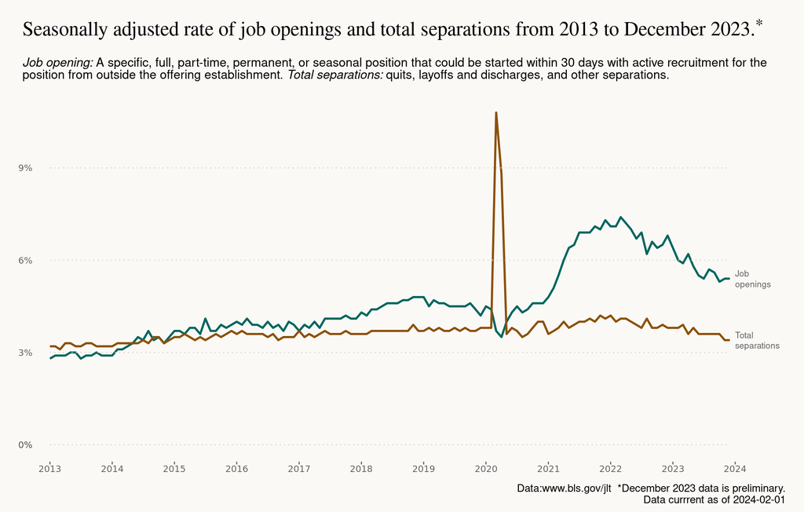

### Levels

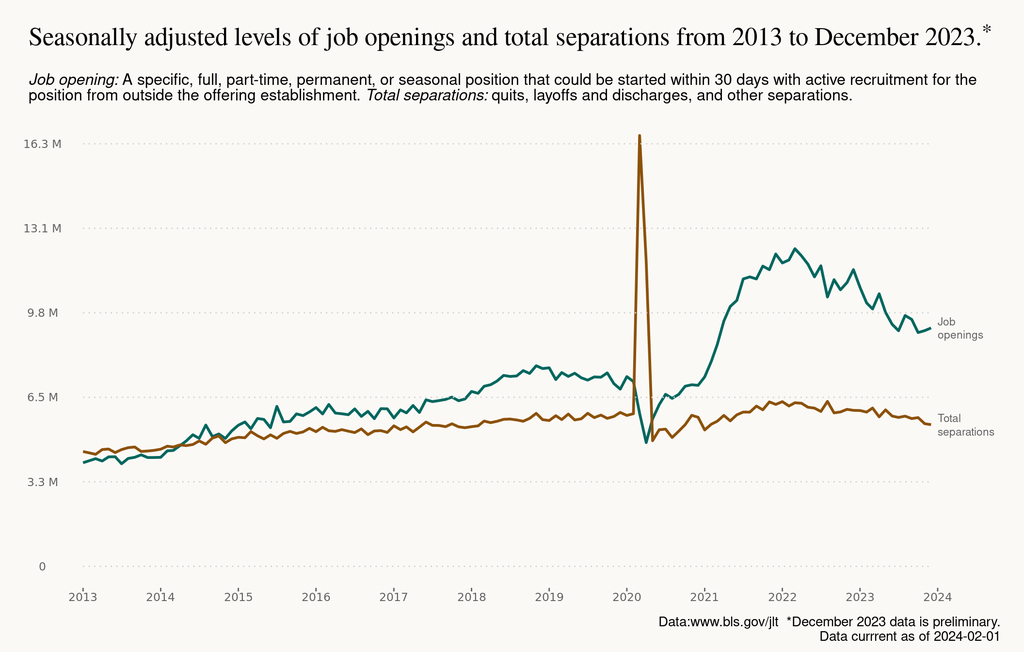

### Data

| Date | Job openings level | Job openings rate | Total separations level | Total separations rate |
| --- | --- | --- | --- | --- |
| December 2023 | 9026000 | 0.05400000000000001 | 5365000 | 0.034 |
| November 2023 | 8925000 | 0.05400000000000001 | 5401000 | 0.034 |
| October 2023 | 8852000 | 0.053 | 5632000 | 0.036 |
| September 2023 | 9350000 | 0.05599999999999999 | 5595000 | 0.036 |
| August 2023 | 9497000 | 0.057 | 5687000 | 0.036 |
| July 2023 | 8920000 | 0.05400000000000001 | 5638000 | 0.036 |
| June 2023 | 9165000 | 0.055 | 5691000 | 0.036 |
| May 2023 | 9616000 | 0.058 | 5925000 | 0.038 |
| April 2023 | 10320000 | 0.06200000000000001 | 5660000 | 0.036 |
| March 2023 | 9745000 | 0.059 | 5994000 | 0.039 |

[output cut: 122 more lines]

##### **Twelve month job openings and separations**

### Rate

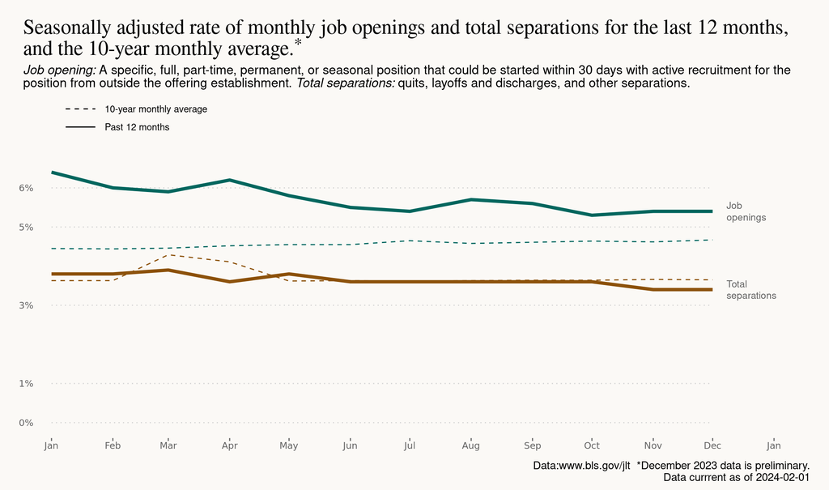

### Levels

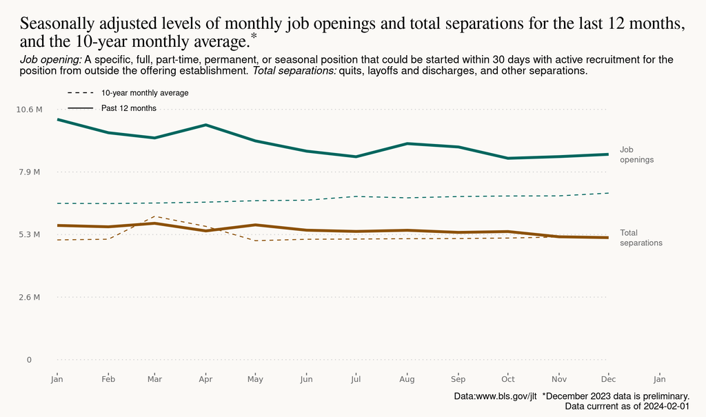

### Data

| Date | Job openings level | Job openings rate | Total separations level | Total separations rate |
| --- | --- | --- | --- | --- |
| December 2023 | 9026000 | 0.05400000000000001 | 5365000 | 0.034 |
| November 2023 | 8925000 | 0.05400000000000001 | 5401000 | 0.034 |
| October 2023 | 8852000 | 0.053 | 5632000 | 0.036 |
| September 2023 | 9350000 | 0.05599999999999999 | 5595000 | 0.036 |
| August 2023 | 9497000 | 0.057 | 5687000 | 0.036 |
| July 2023 | 8920000 | 0.05400000000000001 | 5638000 | 0.036 |
| June 2023 | 9165000 | 0.055 | 5691000 | 0.036 |
| May 2023 | 9616000 | 0.058 | 5925000 | 0.038 |
| April 2023 | 10320000 | 0.06200000000000001 | 5660000 | 0.036 |
| March 2023 | 9745000 | 0.059 | 5994000 | 0.039 |

[output cut: 2 more lines]

### **Job openings, hires, quits, layoffs and discharges**

##### The hires rate rose 0.1% in December, and 0.23% below the ten-year average; there were 5.6 million hires. The quits rate remained flat at 2.2% in December, the lowest rate in 12 months and 0.04% below the ten-year average; there were 3.4 million quits. The layoffs and discharges rate remained flat at 1% in December, the lowest rate in 12 months and 0.18% below the ten-year average; there were 1.6 million layoffs and discharges.

##### **Ten year job openings, hires, quits, layoffs and discharges**

### Rate

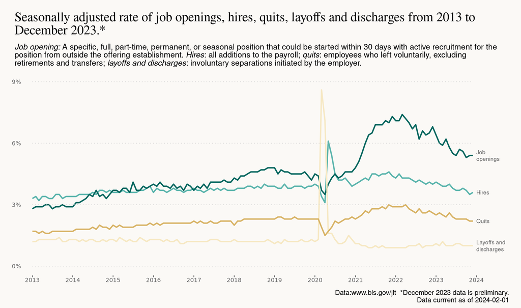

### Level

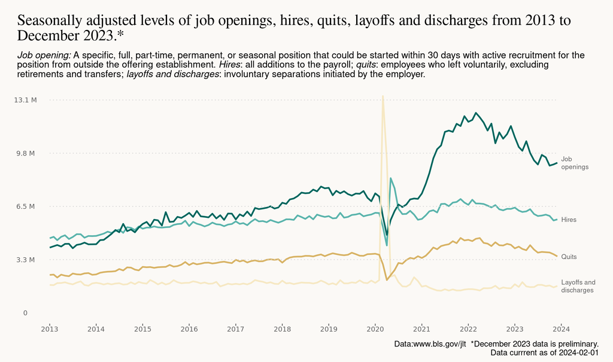

### Data

| Date | Hires level | Hires rate | Quit level | Quit rate | Layoffs and discharges level | Layoffs and discharges rate | Job openings level | Job openings rate |
| --- | --- | --- | --- | --- | --- | --- | --- | --- |
| December 2023 | 5621000 | 0.036 | 3392000 | 0.022 | 1616000 | 0.01 | 9026000 | 0.05400000000000001 |
| November 2023 | 5554000 | 0.035 | 3524000 | 0.022 | 1531000 | 0.01 | 8925000 | 0.05400000000000001 |
| October 2023 | 5828000 | 0.03700000000000001 | 3628000 | 0.023 | 1643000 | 0.01 | 8852000 | 0.053 |
| September 2023 | 5904000 | 0.038 | 3646000 | 0.023 | 1610000 | 0.01 | 9350000 | 0.05599999999999999 |
| August 2023 | 5850000 | 0.03700000000000001 | 3663000 | 0.023 | 1682000 | 0.011 | 9497000 | 0.057 |
| July 2023 | 5822000 | 0.03700000000000001 | 3619000 | 0.023 | 1681000 | 0.011 | 8920000 | 0.05400000000000001 |
| June 2023 | 5940000 | 0.038 | 3802000 | 0.024 | 1551000 | 0.01 | 9165000 | 0.055 |
| May 2023 | 6231000 | 0.04 | 4067000 | 0.026 | 1546000 | 0.01 | 9616000 | 0.058 |
| April 2023 | 6101000 | 0.039 | 3765000 | 0.024 | 1590000 | 0.01 | 10320000 | 0.06200000000000001 |
| March 2023 | 6066000 | 0.039 | 3842000 | 0.025 | 1845000 | 0.012 | 9745000 | 0.059 |

[output cut: 122 more lines]

##### **Twelve month job openings, hires, quits, layoffs and discharges**

### Rate

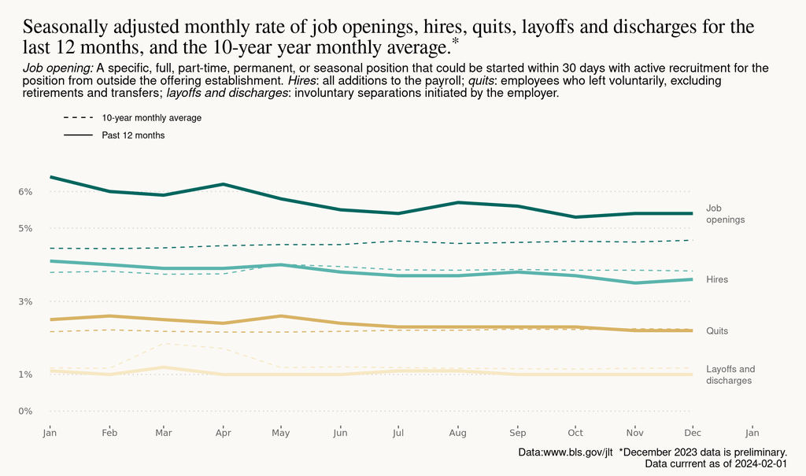

### Level

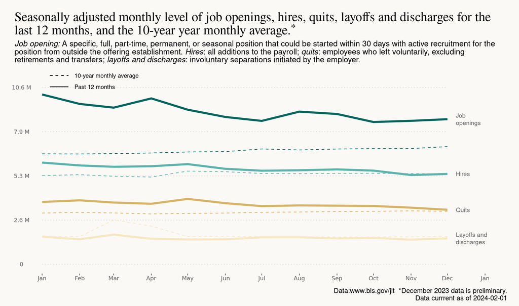

### Data

| Date | Hires level | Hires rate | Layoffs and discharges level | Layoffs and discharges rate | Quit level | Quit rate | Job openings level | Job openings rate |
| --- | --- | --- | --- | --- | --- | --- | --- | --- |
| December 2023 | 5621000 | 0.036 | 1616000 | 0.01 | 3392000 | 0.022 | 9026000 | 0.05400000000000001 |
| November 2023 | 5554000 | 0.035 | 1531000 | 0.01 | 3524000 | 0.022 | 8925000 | 0.05400000000000001 |
| October 2023 | 5828000 | 0.03700000000000001 | 1643000 | 0.01 | 3628000 | 0.023 | 8852000 | 0.053 |
| September 2023 | 5904000 | 0.038 | 1610000 | 0.01 | 3646000 | 0.023 | 9350000 | 0.05599999999999999 |
| August 2023 | 5850000 | 0.03700000000000001 | 1682000 | 0.011 | 3663000 | 0.023 | 9497000 | 0.057 |
| July 2023 | 5822000 | 0.03700000000000001 | 1681000 | 0.011 | 3619000 | 0.023 | 8920000 | 0.05400000000000001 |
| June 2023 | 5940000 | 0.038 | 1551000 | 0.01 | 3802000 | 0.024 | 9165000 | 0.055 |
| May 2023 | 6231000 | 0.04 | 1546000 | 0.01 | 4067000 | 0.026 | 9616000 | 0.058 |
| April 2023 | 6101000 | 0.039 | 1590000 | 0.01 | 3765000 | 0.024 | 10320000 | 0.06200000000000001 |
| March 2023 | 6066000 | 0.039 | 1845000 | 0.012 | 3842000 | 0.025 | 9745000 | 0.059 |

[output cut: 2 more lines]

### Bureau of Labor Statistics [definitions](https://www.bls.gov/jlt/jltdef.htm)

#### **Employment**

##### Includes all persons on the payroll who worked during or received pay for the pay period that includes the 12th of the month:

- Full-time and part-time employees
- Permanent, short-term, and seasonal employees
- Salaried and hourly workers
- Employees on paid vacation or other paid leave

##### Does not include:

- Proprietors and partners of unincorporated businesses
- Unpaid family workers
- Employees on strike for the entire pay period
- Employees on leave without pay for the entire pay period
- Employees of temporary help agencies, employee leasing companies, outside contractors, or consultants. Employees of these types of firms are counted by establishments employing them, not at the site where the work is performed.

#### **Job Openings:**

##### Includes all positions that are open (not filled) on the last business day of the month. A job is “open” only if it meets all three of the following conditions:

- 1.) A specific position exists and there is work available for that position. The position can be full-time or part-time, and it can be permanent, short-term, or seasonal.
- 2.) The job could start within 30 days, whether or not the establishment finds a suitable candidate during that time.
- 3.) There is active recruiting for workers from outside the establishment location that has the opening.

##### Active recruiting means the establishment is taking steps to fill a position. It may include advertising in newspapers, on television, or on radio; posting Internet notices; posting “help wanted” signs; networking with colleagues or making “word of mouth” announcements; accepting applications; interviewing candidates; contacting employment agencies; or soliciting employees at job fairs, state or local employment offices, or similar sources.

##### Job openings do not include:

- Positions open only to internal transfers, promotions or demotions, or recall from layoffs
- Openings for positions with start dates more than 30 days in the future
- Positions for which employees have been hired, but the employees have not yet reported for work
- Positions to be filled by employees of temporary help agencies, employee leasing companies, outside contractors, or consultants. A separate form is used to collect information from temporary help/employee leasing firms for these  
  employees.

##### The job openings rate is computed by dividing the number of job openings by the sum of employment and job openings—that is, all filled and unfilled jobs—and multiplying that quotient by 100.

#### **Hires:**

##### Includes all additions to the payroll during the month:

- Newly hired and rehired employees
- Permanent, short-term, and seasonal employees
- Full-time and part-time employees
- On-call or intermittent employees who returned to work after having been formally separated
- Workers who were hired and separated during the month
- Transfers from other locations
- Employees who were recalled to a job at the sampled establishment following a formal layoff lasting more than 7 days

##### Does not incude:

- Transfers or promotions within the sampled establishment
- Employees returning from strikes
- Employees of temporary help agencies, employee leasing companies, outside contractors, or consultants working at the sampled establishment. A separate form is used to collect information from temporary help and employee leasing firms for these employees.

##### The hires rate is computed by dividing the number of hires by employment and multiplying that quotient by 100.

#### **Separations**

##### Includes all employees separated from the payroll during the month:

- Quits: Employees who left voluntarily. Exception: retirements or transfers to other locations are reported with Other Separations.
- Layoffs & Discharges: Involuntary separations initiated by the employer, including: * Layoffs with no intent to rehire * Discharges because positions were eliminated * Discharges resulting from mergers, downsizing, or plant closings * Firings or other discharges for cause * Terminations of seasonal employees (whether or not they are expected to return next season) * Layoffs (suspensions from pay status) lasting or expected to last more than 7 days. (If the employee was later recalled, they should be reported as a Hire at the time of recall.)
- Other Separations: retirements; transfers to other locations; deaths; or separations due to employee disability

##### Does not include:

- Transfers within the sampled establishment
- Employees on strike
- Employees of temporary help agencies, employee leasing companies, outside contractors, or consultants working at the sampled establishment. These employees are reported by their employer of record.

##### The separations rate is computed by dividing the number of separations by employment and multiplying that quotient by 100. The quits, layoffs and discharges, and other separations rates are computed similarly.